# Final Project

Jenny Gu and Yijiang Zhao

May 14, 2019

# Prevalence of Hate Crimes in Modern Society

We analyzed a data set which detailed all instances of hate crime reported to the **UCR** (Uniform Crime Reporting) and the **NIBRS** (National Incident-Based Reporting System) from 2000 until 2017. These crimes ranged anywhere from intimidation to violent crimes, and were based on various biases, such as race, gender, sexuality, religion, etc.

## Contingency Tables of Race of Perpetrator vs. Race of Victim

One important issue and concern was that surrounding race-based hate crime. Using contingency tables, for both the actual and the expected frequencies, we found that the race of the perpetrator and the race of the victim are not independent.

```r
# Observed
formattable(convert (freqs, tbl))
```

| rn | Anti-American Indian or Alaska Native | Anti-Arab | Anti-Asian | Anti-Black or African American | Anti-Hispanic or Latino | Anti-Multiple Races, Group | Anti-Native Hawaiian or Other Pacific Islander | Anti-Other Race/Ethnicity/Ancestry | Anti-White |
| --- | --- | --- | --- | --- | --- | --- | --- | --- | --- |
| American Indian or Alaska Native | 79 | 1 | 16 | 167 | 70 | 10 | 0 | 38 | 221 |
| Asian | 15 | 5 | 60 | 241 | 54 | 9 | 0 | 72 | 101 |
| Black or African American | 192 | 65 | 368 | 1319 | 1427 | 185 | 7 | 820 | 5812 |
| Multiple | 31 | 11 | 70 | 842 | 179 | 85 | 1 | 157 | 321 |
| Native Hawaiian or Other Pacific Islander | 1 | 0 | 0 | 1 | 4 | 0 | 1 | 1 | 2 |
| Unknown | 620 | 258 | 1338 | 17489 | 2439 | 1874 | 11 | 3314 | 3947 |
| White | 714 | 246 | 1296 | 22351 | 4266 | 884 | 16 | 3102 | 2549 |

```r
# Expected
formattable(convert (exps, Expected))
```

| rn | Anti-American Indian or Alaska Native | Anti-Arab | Anti-Asian | Anti-Black or African American | Anti-Hispanic or Latino | Anti-Multiple Races, Group | Anti-Native Hawaiian or Other Pacific Islander | Anti-Other Race/Ethnicity/Ancestry | Anti-White |
| --- | --- | --- | --- | --- | --- | --- | --- | --- | --- |
| American Indian or Alaska Native | 12.4655803 | 4.42180998 | 23.7540236 | 320.030384 | 63.686137 | 22.9919027 | 0.271647029 | 56.630860 | 97.747656 |
| Asian | 11.5337679 | 4.09127601 | 21.9783906 | 296.107847 | 58.925545 | 21.2732389 | 0.251341188 | 52.397656 | 90.440938 |
| Black or African American | 211.1072951 | 74.88430684 | 402.2795187 | 5419.783655 | 1078.538481 | 389.3728378 | 4.600401103 | 959.055841 | 1655.377664 |
| Multiple | 35.1396841 | 12.46480321 | 66.9610930 | 902.145450 | 179.527200 | 64.8127225 | 0.765755829 | 159.638819 | 275.544472 |
| Native Hawaiian or Other Pacific Islander | 0.2070694 | 0.07345199 | 0.3945851 | 5.316119 | 1.057909 | 0.3819253 | 0.004512409 | 0.940712 | 1.623715 |
| Unknown | 647.9202808 | 229.83128604 | 1234.6568062 | 16634.137378 | 3310.198045 | 1195.0442467 | 14.119328152 | 2943.487716 | 5080.604914 |
| White | 733.5227877 | 260.19633993 | 1397.7782903 | 18831.821108 | 3747.537729 | 1352.9321634 | 15.984758085 | 3332.378040 | 5751.848784 |

We performed a chi-squared test to further display this and found a p-value of <2.2E-16, which is statistically significant on all levels (i.e. 0.1, 0.05, and 0.01). Therefore, the race of the perpetrator and the race of the victim are not independent.

```r
chisq.test(offender, victim)
```

```
##
##  Pearson's Chi-squared test
##
## data:  offender and victim
## X-squared = 18412, df = 56, p-value < 2.2e-16
```

## How Much Hate?

One preliminary analysis we wanted to do was see how the distribution of the number of hate crimes in each city. To keep the overall population of a city constant, we only selected the hate crime data for cities with a population of 250,000 to 499,999 and created a histogram. We fitted a normal curve over the distribution and found that it was not normal.

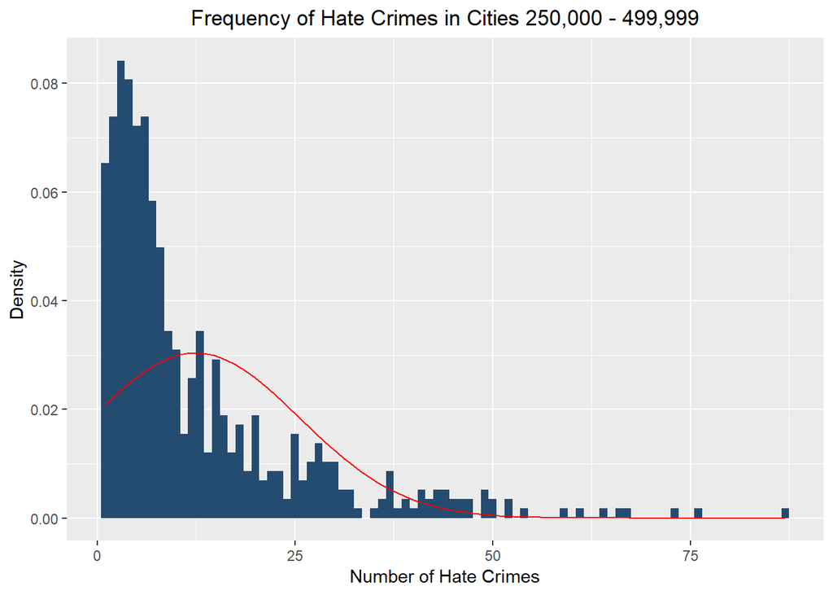

We then overlaid a chi distribution (green), gamma distribution (red), and an exponential distribution (blue), finding that the gamma function fit best.

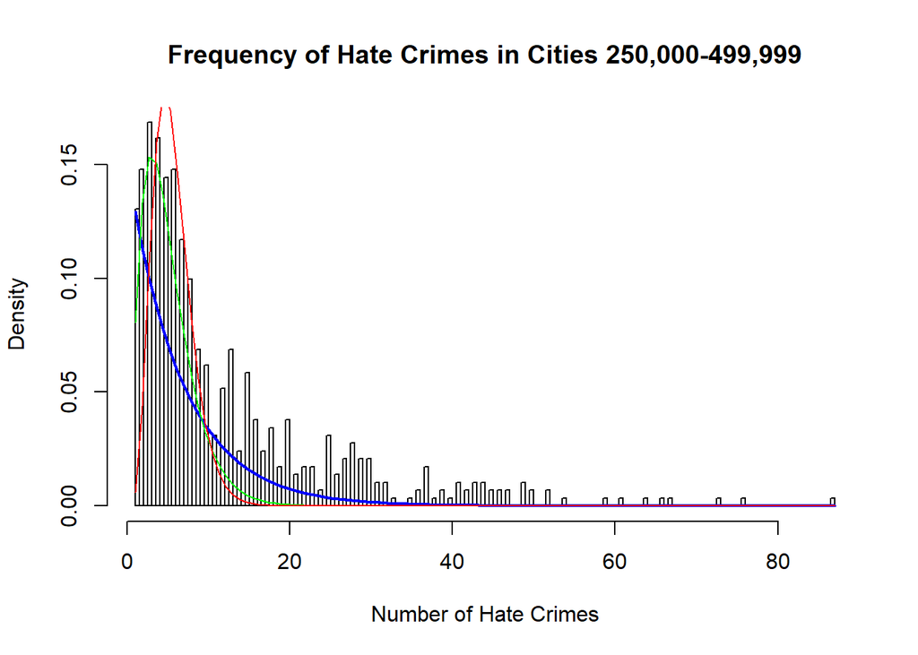

However, by taking 10000 samples of 10 data points and averaging the total numbers of hate crime for each sample, the means of each of those samples better fit a normal distribution, per the central limit theorem. When plotting the normal distribution (red) and the gamma function (green), we found that the gamma function still fits slightly better.

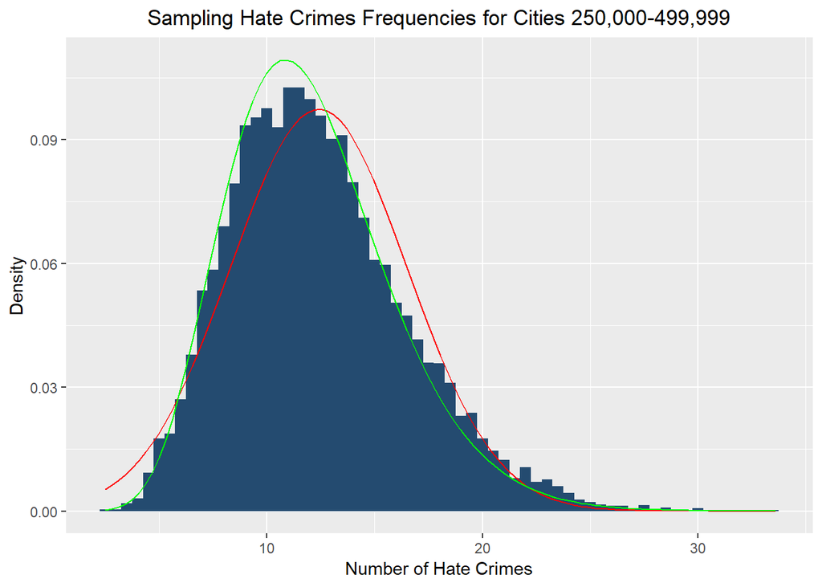

```r
skewness(avgHC, type=1)
```

```
## [1] 0.6488926
```

## National Frequencies of Hate Crime Throughout Time

Another issue of concern was how hate crime changed over time. We first created a barplot which displayed the national counts of instances of hate crime for each year.

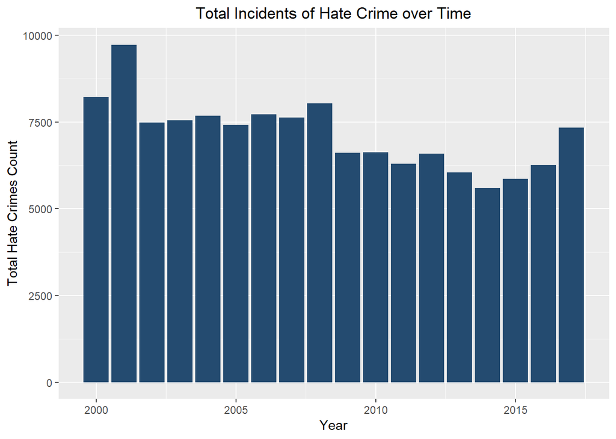

We discovered that 2001 seemed somewhat higher in the number of hate crimes and performed statistical analysis and found that it was indeed significantly higher.

```r
# observed difference in 2001
obsDiff2001
```

```
## [1] 2732.706
```

```r
N <- 10000
# mean of differences
mean2001
```

```
## [1] 0.01062353
```

```r
# pvalue
pvalue2001 <- (sum(abs(diffs) >= abs(obsDiff2001))+1)/(N+1)
pvalue2001
```

```
## [1] 9.999e-05
```

The p-value from the permutation test is statistically significant under all alpha levels (0.1, 0.05, 0.01).  
To explore what might be driving this increase in hate crimes, we hypothesized that it could be the result of Anti-Islam and Anti-Arab hate crimes increasing as the result of 9/11.  
To make sure that the increase in hate crimes in 2001 was actually due to 9/11, we first had to verify that other hate crime biases did not change significantly during that time. Graphing anti-Black and anti-White hate crimes over time verified that those kinds of biases did not change, and that the increase in 2001 was due to increased anti-Islam and anti-Arab hate crimes.

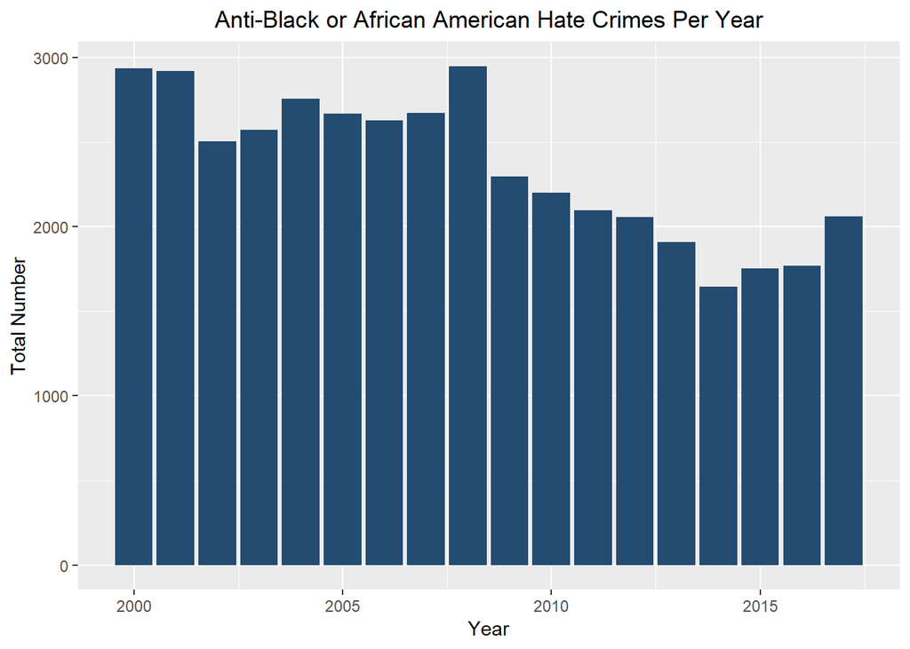

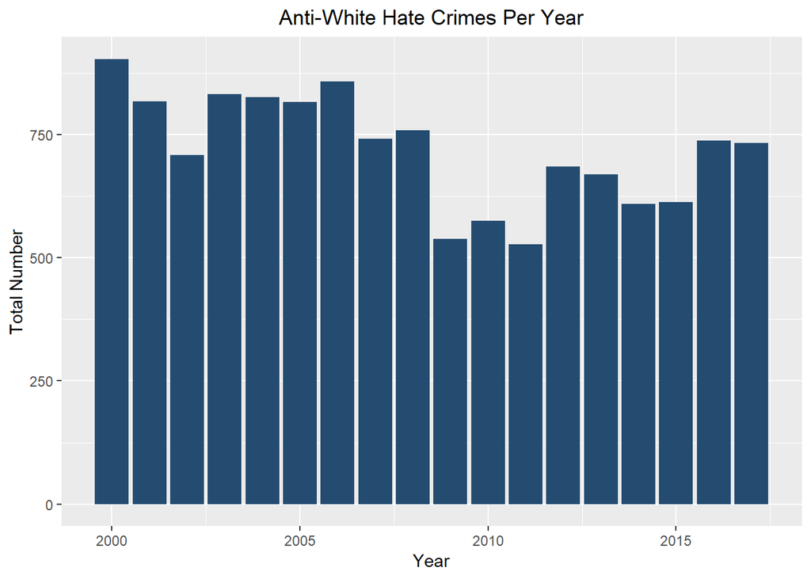

Instead, we found there was a significant spike in the number of Anti-Islam and Anti-Arab hate crimes following 9/11.

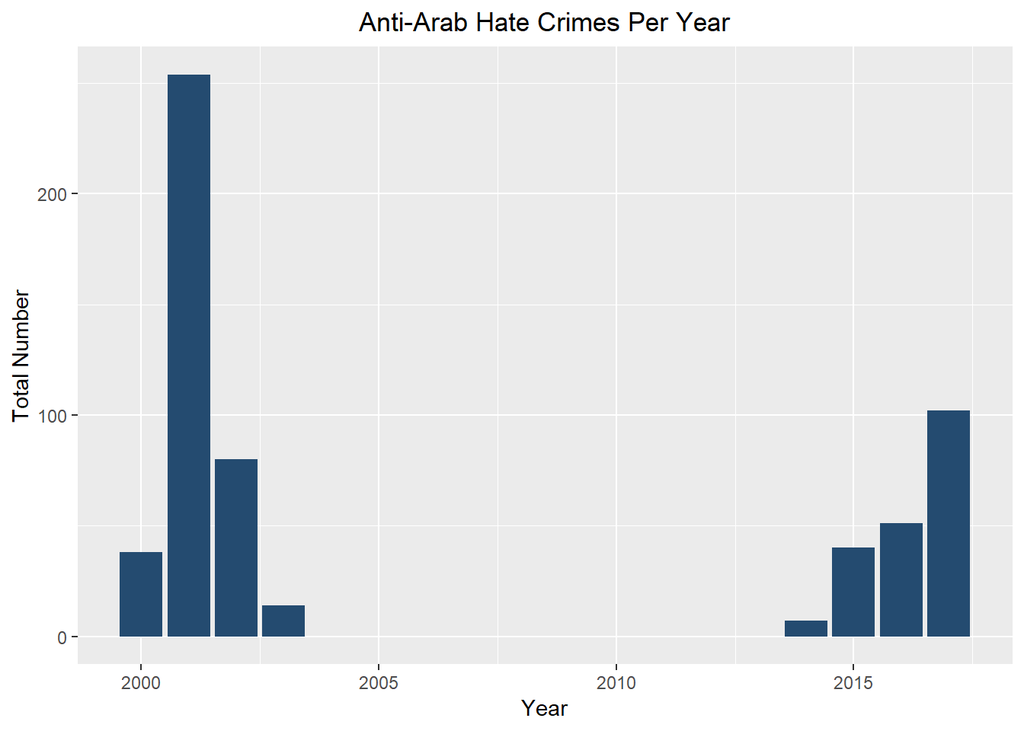

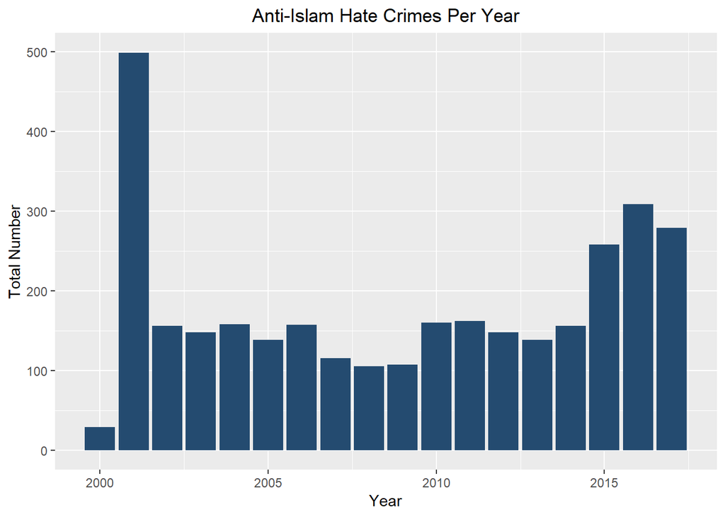

Then, to further explore what the causes might have been, we found the counts of incidents of hate crime for each month, and discovered a few important trends.  
First, we found that the frequencies of hate crime on a national scale is very cyclical, typically increasing during spring and decreasing sharply as we approach the end of the year, presumably because of winter or because of end-of-year festivities such as Thanksgiving and Christmas.

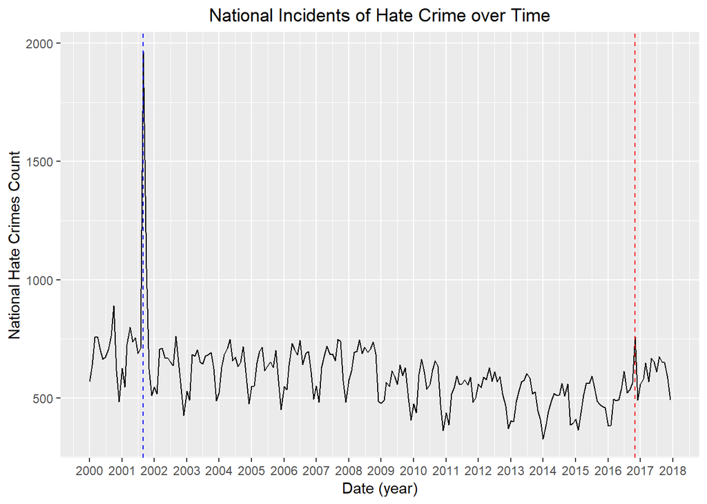

Secondly, from the graph, we discovered a large spike in hate crimes near the end of the year 2001. The dashed blue line is the month of 9/11, which suggests that (in the U.S., not including the terrorist attack) the reason for the *significant* spike is due to 9/11. Additionally, we noticed that beginning from 2016, the incidents of hate crime no longer followed the generally decreasing but somewhat cyclical counts of hate crime. The dashed red line is the month that Trump was elected as president, and we also observe a spike that month.  
Additionally, we did not see it drop as much as we would have expected (given that the number of incidents drops towards the end of the year).